# Parte_2

### Exercise 5

1. Get a polygons map of the lowest administrative unit possible.
2. Get a table of variables for those units. At least 3 numerical variables.
3. Preprocess both tables and get them ready for merging.
4. Do the merging, making the changes needed so that you keep the most rows.

```python
import geopandas as gpd
depas=gpd.read_file('https://github.com/valeriacaroe/Parte2/raw/refs/heads/main/departamento/departamentoPolygon.shp')
pobreza=gpd.read_file('https://github.com/valeriacaroe/Parte2/raw/refs/heads/main/Pobreza%20Cr%C3%B3nica%20x%20Departamento/Pobreza%20Cr%C3%B3nica%20X%20Departamento.shp')
```

```python
pobreza.columns
```

```
Index(['LINK_DEPTO', 'PROVINCIA_', 'DEPTO_FIRS', 'PC_HOG', 'PC_PER',
       'P_PC_PER', 'P_PC_HOG', 'PC_INCID_V', 'N_HOGARES', 'POBLACION', 'PEA',
       'P_HAC4_HOG', 'P_CASAB_HO', 'P_DEFCLO_H', 'P_JPRIMCOM', 'P_JSECINC_',
       'P_N_NOASIS', 'P_DEF_SAL2', 'IDPROV', 'PROV', 'IDDPTO', 'DPTO',
       'DEPARTAMEN', 'DEPARTAM_1', 'DEPARTAM_2', 'DEPARTAM_3', 'DEPARTAM_4',
       'geometry'],
      dtype='object')
```

```python
pobreza=pobreza.drop(columns=['LINK_DEPTO','PROVINCIA_','DEPARTAM_1','DEPARTAM_2','DEPARTAM_3','DEPARTAM_4' ])
```

```python
pobreza
```

|  | DEPTO_FIRS | PC_HOG | PC_PER | P_PC_PER | P_PC_HOG | PC_INCID_V | N_HOGARES | POBLACION | PEA | P_HAC4_HOG | ... | P_JPRIMCOM | P_JSECINC_ | P_N_NOASIS | P_DEF_SAL2 | IDPROV | PROV | IDDPTO | DPTO | DEPARTAMEN | geometry |
| --- | --- | --- | --- | --- | --- | --- | --- | --- | --- | --- | --- | --- | --- | --- | --- | --- | --- | --- | --- | --- | --- |
| 0 | Comuna 01 | 1166.0 | 6690.0 | 3.55 | 1.38 | 2.0 | 84468 | 188280 | 119373 | 3.49 | ... | 18.93 | 31.01 | 4.30 | 27.79 | 02 | Ciudad Autónoma de Buenos Aires | 02001 | Comuna 1 | 205886 | POLYGON ((-58.3863 -34.57819, -58.38606 -34.57... |
| 1 | Comuna 02 | 48.0 | 278.0 | 0.18 | 0.06 | 1.0 | 73156 | 150069 | 96398 | 0.44 | ... | 6.84 | 11.65 | 1.49 | 7.56 | 02 | Ciudad Autónoma de Buenos Aires | 02002 | Comuna 2 | 157932 | POLYGON ((-58.38111 -34.56912, -58.3811 -34.56... |
| 2 | Comuna 03 | 460.0 | 2668.0 | 1.46 | 0.57 | 2.0 | 80489 | 181518 | 115726 | 2.13 | ... | 18.22 | 30.21 | 2.91 | 20.95 | 02 | Ciudad Autónoma de Buenos Aires | 02003 | Comuna 3 | 187537 | POLYGON ((-58.41192 -34.598, -58.4103 -34.5980... |
| 3 | Comuna 04 | 1226.0 | 7619.0 | 3.53 | 1.60 | 2.0 | 76455 | 215452 | 123727 | 3.57 | ... | 31.70 | 48.39 | 4.17 | 32.94 | 02 | Ciudad Autónoma de Buenos Aires | 02004 | Comuna 4 | 218245 | MULTIPOLYGON (((-58.35525 -34.61933, -58.35515... |
| 4 | Comuna 05 | 217.0 | 1271.0 | 0.72 | 0.28 | 1.0 | 76846 | 175012 | 111960 | 1.06 | ... | 15.34 | 25.82 | 2.18 | 14.06 | 02 | Ciudad Autónoma de Buenos Aires | 02005 | Comuna 5 | 179005 | POLYGON ((-58.41726 -34.59783, -58.41616 -34.5... |
| ... | ... | ... | ... | ... | ... | ... | ... | ... | ... | ... | ... | ... | ... | ... | ... | ... | ... | ... | ... | ... | ... |
| 520 | Tafi Viejo | 1426.0 | 9800.0 | 8.06 | 4.78 | 3.0 | 29772 | 121479 | 53411 | 5.30 | ... | 50.98 | 67.62 | 6.91 | 40.40 | 90 | Tucumán | 90105 | Tafí Viejo | 121638 | POLYGON ((-65.68726 -26.52624, -65.68502 -26.5... |
| 521 | Trancas | 391.0 | 2725.0 | 15.80 | 8.80 | 5.0 | 4441 | 17239 | 6584 | 7.70 | ... | 75.72 | 84.10 | 8.09 | 52.72 | 90 | Tucumán | 90112 | Trancas | 17371 | POLYGON ((-65.35699 -26.0583, -65.35612 -26.05... |
| 522 | Yerba Buena | 466.0 | 3219.0 | 4.31 | 2.51 | 2.0 | 18560 | 74639 | 36523 | 3.16 | ... | 34.71 | 45.51 | 4.34 | 26.79 | 90 | Tucumán | 90119 | Yerba Buena | 75076 | POLYGON ((-65.41456 -26.73772, -65.41434 -26.7... |
| 523 | Rio Grande | 85.0 | 544.0 | 0.78 | 0.39 | 1.0 | 21410 | 69465 | 38498 | 2.29 | ... | 28.96 | 49.27 | 1.72 | 26.43 | 94 | Tierra del Fuego, Antártida e Islas del Atlánt... | 94007 | Río Grande | 70042 | POLYGON ((-68.26234 -53.00262, -68.26107 -53.0... |
| 524 | Ushuaia | 52.0 | 329.0 | 0.60 | 0.29 | 1.0 | 17538 | 54522 | 31165 | 2.42 | ... | 22.11 | 42.02 | 1.59 | 27.17 | 94 | Tierra del Fuego, Antártida e Islas del Atlánt... | 94014 | Ushuaia | 56956 | MULTIPOLYGON (((-64.3168 -54.72424, -64.31501 ... |

525 rows × 22 columns

```python
pobreza.info()
```

```
<class 'geopandas.geodataframe.GeoDataFrame'>
RangeIndex: 525 entries, 0 to 524
Data columns (total 22 columns):
 #   Column      Non-Null Count  Dtype
---  ------      --------------  -----
 0   DEPTO_FIRS  525 non-null    object
 1   PC_HOG      525 non-null    float64
 2   PC_PER      525 non-null    float64
 3   P_PC_PER    525 non-null    float64
 4   P_PC_HOG    525 non-null    float64
 5   PC_INCID_V  525 non-null    float64
 6   N_HOGARES   525 non-null    int32
 7   POBLACION   525 non-null    int32
 8   PEA         525 non-null    int32
 9   P_HAC4_HOG  525 non-null    float64
 10  P_CASAB_HO  525 non-null    float64
 11  P_DEFCLO_H  525 non-null    float64
 12  P_JPRIMCOM  525 non-null    float64
 13  P_JSECINC_  525 non-null    float64
 14  P_N_NOASIS  525 non-null    float64
 15  P_DEF_SAL2  525 non-null    float64
 16  IDPROV      525 non-null    object
 17  PROV        525 non-null    object
 18  IDDPTO      525 non-null    object
 19  DPTO        525 non-null    object
 20  DEPARTAMEN  525 non-null    int64
 21  geometry    525 non-null    geometry
dtypes: float64(12), geometry(1), int32(3), int64(1), object(5)
memory usage: 84.2+ KB
```

```python
clean_column_names = lambda df: df.columns.astype(str).str.strip().str.replace(pat=r'\s', repl='_', regex=True)

pobreza.columns = clean_column_names(pobreza)
```

```python
pobreza=pobreza[['DEPTO_FIRS', 'N_HOGARES', 'POBLACION','P_PC_HOG', 'geometry']]
```

```python
depas
```

|  | gid | objeto | fna | gna | nam | in1 | fdc | sag | geometry |
| --- | --- | --- | --- | --- | --- | --- | --- | --- | --- |
| 0 | 38 | Departamento | Departamento Ojo de Agua | Departamento | Ojo de Agua | 86126 | Catastro Provinciales | IGN | POLYGON ((-64.05988 -28.85665, -64.0579 -28.85... |
| 1 | 39 | Departamento | Departamento Choya | Departamento | Choya | 86063 | Catastro Provinciales | IGN | POLYGON ((-64.62099 -28.16594, -64.5405 -28.17... |
| 2 | 65 | Departamento | Partido de Lezama | Partido | Lezama | 06466 | ARBA - Gerencia de Servicios Catastrales | IGN | POLYGON ((-57.86023 -35.68635, -57.85231 -35.6... |
| 3 | 102 | Departamento | Departamento Pilcaniyeu | Departamento | Pilcaniyeu | 62070 | IDE Rio Negro | IGN | POLYGON ((-69.75504 -39.87796, -69.75504 -39.8... |
| 4 | 118 | Departamento | Comuna 1 | Comuna | Comuna 1 | 02007 | Direc. de Catastro | IGN | POLYGON ((-58.38609 -34.57823, -58.38592 -34.5... |
| ... | ... | ... | ... | ... | ... | ... | ... | ... | ... |
| 525 | 529 | Departamento | Departamento Constitución | Departamento | Constitución | 82028 | Servicio de Catastro e Información Territorial | IGN | POLYGON ((-60.28688 -33.21659, -60.29236 -33.2... |
| 526 | 530 | Departamento | Departamento San Justo | Departamento | San Justo | 82112 | Servicio de Catastro e Información Territorial | IGN | POLYGON ((-60.6417 -29.92194, -60.6112 -29.926... |
| 527 | 489 | Departamento | Partido de La Plata | Partido | La Plata | 06441 | ARBA - Gerencia de Servicios Catastrales | IGN | MULTIPOLYGON (((-57.99666 -34.87535, -57.99087... |
| 528 | 490 | Departamento | Departamento Mercedes | Departamento | Mercedes | 18105 | IGN | IGN | POLYGON ((-57.21562 -28.49937, -57.21562 -28.4... |
| 529 | 491 | Departamento | Departamento Santa Bárbara | Departamento | Santa Bárbara | 38070 | Direc. Grl. de Inmuebles | IGN | POLYGON ((-64.15788 -23.63338, -64.15865 -23.7... |

530 rows × 9 columns

```python
depas=depas[['fna']]
```

```python
depas
```

|  | fna |
| --- | --- |
| 0 | Departamento Ojo de Agua |
| 1 | Departamento Choya |
| 2 | Partido de Lezama |
| 3 | Departamento Pilcaniyeu |
| 4 | Comuna 1 |
| ... | ... |
| 525 | Departamento Constitución |
| 526 | Departamento San Justo |
| 527 | Partido de La Plata |
| 528 | Departamento Mercedes |
| 529 | Departamento Santa Bárbara |

530 rows × 1 columns

```python
onlyPobreza=set(pobreza.DEPTO_FIRS)-set(depas.fna)
onlyPobreza
```

```
{'12 de Octubre',
 '1° de Mayo',
 '2 de Abril',
 '25 de Mayo',
 '9 de Julio',
 'Adolfo Alsina',
 'Adolfo Gonzales Chaves',
 'Aguirre',
 'Albardon',
 'Alberdi',
 'Alberti',
 'Almirante Brown',
 'Alumine',
 'Ambato',
 'Ancasti',
 'Andalgala',
 'Anelo',
 'Angaco',
 'Anta',
 'Antofagasta de la Sierra',
 'Apostoles',
 'Arauco',
 'Arrecifes',
 'Atamisqui',
 'Atreuco',
 'Avellaneda',
 'Ayacucho',
 'Azul',
 'Bahia Blanca',
 'Balcarce',
 'Banda',
 'Baradero',
 'Bariloche',
 'Belen',
 'Belgrano',
 'Bella Vista',
 'Benito Juarez',
 'Berazategui',
 'Berisso',
 'Bermejo',
```

[output cut: 381 more lines]

```
 'Valle Fertil',
 'Valle Grande',
 'Valle Viejo',
 'Vera',
 'Vicente Lopez',
 'Victoria',
 'Villa Gesell',
 'Villaguay',
 'Villarino',
 'Vinchina',
 'Yavi',
 'Yerba Buena',
 'Zapala',
 'Zarate',
 'Zonda'}
```

```python
onlyDepas=set(depas.fna)-set(pobreza.DEPTO_FIRS)
onlyDepas
```

```
{'Comuna 1',
 'Comuna 2',
 'Comuna 3',
 'Comuna 4',
 'Comuna 5',
 'Comuna 6',
 'Comuna 7',
 'Comuna 8',
 'Comuna 9',
 'Departamento 12 de Octubre',
 'Departamento 1° de Mayo',
 'Departamento 2 de Abril',
 'Departamento 25 de Mayo',
 'Departamento 9 de Julio',
 'Departamento Adolfo Alsina',
 'Departamento Aguirre',
 'Departamento Albardón',
 'Departamento Alberdi',
 'Departamento Almirante Brown',
 'Departamento Aluminé',
 'Departamento Ambato',
 'Departamento Ancasti',
 'Departamento Andalgalá',
 'Departamento Angaco',
 'Departamento Anta',
 'Departamento Antofagasta de la Sierra',
 'Departamento Antártida Argentina',
 'Departamento Apóstoles',
 'Departamento Arauco',
 'Departamento Atamisqui',
 'Departamento Atreucó',
 'Departamento Avellaneda',
 'Departamento Ayacucho',
 'Departamento Añelo',
 'Departamento Banda',
 'Departamento Bariloche',
 'Departamento Belgrano',
 'Departamento Bella Vista',
 'Departamento Belén',
 'Departamento Bermejo',
```

[output cut: 411 more lines]

```
 'Partido de San Vicente',
 'Partido de Suipacha',
 'Partido de Tandil',
 'Partido de Tapalqué',
 'Partido de Tigre',
 'Partido de Tordillo',
 'Partido de Tornquist',
 'Partido de Trenque Lauquen',
 'Partido de Tres Arroyos',
 'Partido de Tres Lomas',
 'Partido de Tres de Febrero',
 'Partido de Vicente López',
 'Partido de Villa Gesell',
 'Partido de Villarino',
 'Partido de Zárate'}
```

```python
!pip install thefuzz -q
from thefuzz import process as fz
```

```
   ━━━━━━━━━━━━━━━━━━━━━━━━━━━━━━━━━━━━━━━━ 3.1/3.1 MB 35.3 MB/s eta 0:00:00
```

```python
[(item, fz.extractOne(item,onlyDepas)) for item in sorted(onlyPobreza)]
```

```
[('12 de Octubre', ('Departamento 12 de Octubre', 90)),
 ('1° de Mayo', ('Partido de Tres Lomas', 86)),
 ('2 de Abril', ('Departamento 2 de Abril', 90)),
 ('25 de Mayo', ('Partido de 25 de Mayo', 90)),
 ('9 de Julio', ('Partido de 9 de Julio', 90)),
 ('Adolfo Alsina', ('Departamento Adolfo Alsina', 90)),
 ('Adolfo Gonzales Chaves', ('Partido de Adolfo Gonzales Chaves', 90)),
 ('Aguirre', ('Departamento Aguirre', 90)),
 ('Albardon', ('Departamento Albardón', 84)),
 ('Alberdi', ('Departamento Juan Bautista Alberdi', 90)),
 ('Alberti', ('Partido de Alberti', 90)),
 ('Almirante Brown', ('Partido de Almirante Brown', 90)),
 ('Alumine', ('Departamento Aluminé', 83)),
 ('Ambato', ('Departamento Ambato', 90)),
 ('Ancasti', ('Departamento Ancasti', 90)),
 ('Andalgala', ('Departamento Andalgalá', 85)),
 ('Anelo', ('Departamento Añelo', 80)),
 ('Angaco', ('Departamento Angaco', 90)),
 ('Anta', ('Departamento Santa Bárbara', 90)),
 ('Antofagasta de la Sierra', ('Departamento Antofagasta de la Sierra', 90)),
 ('Apostoles', ('Departamento Apóstoles', 85)),
 ('Arauco', ('Departamento Arauco', 90)),
 ('Arrecifes', ('Partido de Arrecifes', 90)),
 ('Atamisqui', ('Departamento Atamisqui', 90)),
 ('Atreuco', ('Departamento Atreucó', 83)),
 ('Avellaneda', ('Partido de Avellaneda', 90)),
 ('Ayacucho', ('Partido de Ayacucho', 90)),
 ('Azul', ('Partido de Azul', 90)),
 ('Bahia Blanca', ('Partido de Bahía Blanca', 86)),
 ('Balcarce', ('Partido de Balcarce', 90)),
 ('Banda', ('Departamento Banda', 90)),
 ('Baradero', ('Partido de Baradero', 90)),
 ('Bariloche', ('Departamento Bariloche', 90)),
 ('Belen', ('Departamento Belén', 80)),
 ('Belgrano', ('Departamento Belgrano', 90)),
 ('Bella Vista', ('Departamento Bella Vista', 90)),
 ('Benito Juarez', ('Partido de Benito Juárez', 86)),
 ('Berazategui', ('Partido de Berazategui', 90)),
 ('Berisso', ('Partido de Berisso', 90)),
 ('Bermejo', ('Departamento Bermejo', 90)),
```

[output cut: 385 more lines]

```
 ('Valle Fertil', ('Departamento Valle Fértil', 86)),
 ('Valle Grande', ('Departamento Valle Grande', 90)),
 ('Valle Viejo', ('Departamento Valle Viejo', 90)),
 ('Vera', ('Departamento Vera', 90)),
 ('Vicente Lopez', ('Partido de Vicente López', 86)),
 ('Victoria', ('Departamento Victoria', 90)),
 ('Villa Gesell', ('Partido de Villa Gesell', 90)),
 ('Villaguay', ('Departamento Villaguay', 90)),
 ('Villarino', ('Partido de Villarino', 90)),
 ('Vinchina', ('Departamento Vinchina', 90)),
 ('Yavi', ('Departamento Yavi', 90)),
 ('Yerba Buena', ('Departamento Yerba Buena', 90)),
 ('Zapala', ('Departamento Zapala', 90)),
 ('Zarate', ('Partido de Zárate', 82)),
 ('Zonda', ('Departamento Zonda', 90))]
```

```python
# Se ve que la mayoría de discordancias entre nombres se da cuando la concordancia es menor a 86
[(item, fz.extractOne(item,onlyDepas)) for item in sorted(onlyPobreza)
 if fz.extractOne(item, onlyDepas)[1]>86]
```

```
[('12 de Octubre', ('Departamento 12 de Octubre', 90)),
 ('2 de Abril', ('Departamento 2 de Abril', 90)),
 ('25 de Mayo', ('Partido de 25 de Mayo', 90)),
 ('9 de Julio', ('Partido de 9 de Julio', 90)),
 ('Adolfo Alsina', ('Departamento Adolfo Alsina', 90)),
 ('Adolfo Gonzales Chaves', ('Partido de Adolfo Gonzales Chaves', 90)),
 ('Aguirre', ('Departamento Aguirre', 90)),
 ('Alberdi', ('Departamento Juan Bautista Alberdi', 90)),
 ('Alberti', ('Partido de Alberti', 90)),
 ('Almirante Brown', ('Partido de Almirante Brown', 90)),
 ('Ambato', ('Departamento Ambato', 90)),
 ('Ancasti', ('Departamento Ancasti', 90)),
 ('Angaco', ('Departamento Angaco', 90)),
 ('Anta', ('Departamento Santa Bárbara', 90)),
 ('Antofagasta de la Sierra', ('Departamento Antofagasta de la Sierra', 90)),
 ('Arauco', ('Departamento Arauco', 90)),
 ('Arrecifes', ('Partido de Arrecifes', 90)),
 ('Atamisqui', ('Departamento Atamisqui', 90)),
 ('Avellaneda', ('Partido de Avellaneda', 90)),
 ('Ayacucho', ('Partido de Ayacucho', 90)),
 ('Azul', ('Partido de Azul', 90)),
 ('Balcarce', ('Partido de Balcarce', 90)),
 ('Banda', ('Departamento Banda', 90)),
 ('Baradero', ('Partido de Baradero', 90)),
 ('Bariloche', ('Departamento Bariloche', 90)),
 ('Belgrano', ('Departamento Belgrano', 90)),
 ('Bella Vista', ('Departamento Bella Vista', 90)),
 ('Berazategui', ('Partido de Berazategui', 90)),
 ('Berisso', ('Partido de Berisso', 90)),
 ('Bermejo', ('Departamento Bermejo', 90)),
 ('Beron de Astrada', ('Departamento Berón de Astrada', 87)),
 ('Biedma', ('Departamento Biedma', 90)),
 ('Bragado', ('Partido de Bragado', 90)),
 ('Brandsen', ('Partido de Brandsen', 90)),
 ('Cachi', ('Departamento Cachi', 90)),
 ('Cafayate', ('Departamento Cafayate', 90)),
 ('Calamuchita', ('Departamento Calamuchita', 90)),
 ('Caleu Caleu', ('Departamento Caleu Caleu', 90)),
 ('Calingasta', ('Departamento Calingasta', 90)),
 ('Campana', ('Partido de Campana', 90)),
```

[output cut: 263 more lines]

```
 ('Uruguay', ('Departamento Uruguay', 90)),
 ('Ushuaia', ('Departamento Ushuaia', 90)),
 ('Valcheta', ('Departamento Valcheta', 90)),
 ('Valle Grande', ('Departamento Valle Grande', 90)),
 ('Valle Viejo', ('Departamento Valle Viejo', 90)),
 ('Vera', ('Departamento Vera', 90)),
 ('Victoria', ('Departamento Victoria', 90)),
 ('Villa Gesell', ('Partido de Villa Gesell', 90)),
 ('Villaguay', ('Departamento Villaguay', 90)),
 ('Villarino', ('Partido de Villarino', 90)),
 ('Vinchina', ('Departamento Vinchina', 90)),
 ('Yavi', ('Departamento Yavi', 90)),
 ('Yerba Buena', ('Departamento Yerba Buena', 90)),
 ('Zapala', ('Departamento Zapala', 90)),
 ('Zonda', ('Departamento Zonda', 90))]
```

```python
changes1={item:fz.extractOne(item, onlyDepas)[0]
                 for item in sorted(onlyPobreza)
                 if fz.extractOne(item, onlyDepas)[1] >86}
#dict of matches
changes1
```

```
{'12 de Octubre': 'Departamento 12 de Octubre',
 '2 de Abril': 'Departamento 2 de Abril',
 '25 de Mayo': 'Partido de 25 de Mayo',
 '9 de Julio': 'Partido de 9 de Julio',
 'Adolfo Alsina': 'Departamento Adolfo Alsina',
 'Adolfo Gonzales Chaves': 'Partido de Adolfo Gonzales Chaves',
 'Aguirre': 'Departamento Aguirre',
 'Alberdi': 'Departamento Juan Bautista Alberdi',
 'Alberti': 'Partido de Alberti',
 'Almirante Brown': 'Partido de Almirante Brown',
 'Ambato': 'Departamento Ambato',
 'Ancasti': 'Departamento Ancasti',
 'Angaco': 'Departamento Angaco',
 'Anta': 'Departamento Santa Bárbara',
 'Antofagasta de la Sierra': 'Departamento Antofagasta de la Sierra',
 'Arauco': 'Departamento Arauco',
 'Arrecifes': 'Partido de Arrecifes',
 'Atamisqui': 'Departamento Atamisqui',
 'Avellaneda': 'Partido de Avellaneda',
 'Ayacucho': 'Partido de Ayacucho',
 'Azul': 'Partido de Azul',
 'Balcarce': 'Partido de Balcarce',
 'Banda': 'Departamento Banda',
 'Baradero': 'Partido de Baradero',
 'Bariloche': 'Departamento Bariloche',
 'Belgrano': 'Departamento Belgrano',
 'Bella Vista': 'Departamento Bella Vista',
 'Berazategui': 'Partido de Berazategui',
 'Berisso': 'Partido de Berisso',
 'Bermejo': 'Departamento Bermejo',
 'Beron de Astrada': 'Departamento Berón de Astrada',
 'Biedma': 'Departamento Biedma',
 'Bragado': 'Partido de Bragado',
 'Brandsen': 'Partido de Brandsen',
 'Cachi': 'Departamento Cachi',
 'Cafayate': 'Departamento Cafayate',
 'Calamuchita': 'Departamento Calamuchita',
 'Caleu Caleu': 'Departamento Caleu Caleu',
 'Calingasta': 'Departamento Calingasta',
 'Campana': 'Partido de Campana',
```

[output cut: 262 more lines]

```
 'Uruguay': 'Departamento Uruguay',
 'Ushuaia': 'Departamento Ushuaia',
 'Valcheta': 'Departamento Valcheta',
 'Valle Grande': 'Departamento Valle Grande',
 'Valle Viejo': 'Departamento Valle Viejo',
 'Vera': 'Departamento Vera',
 'Victoria': 'Departamento Victoria',
 'Villa Gesell': 'Partido de Villa Gesell',
 'Villaguay': 'Departamento Villaguay',
 'Villarino': 'Partido de Villarino',
 'Vinchina': 'Departamento Vinchina',
 'Yavi': 'Departamento Yavi',
 'Yerba Buena': 'Departamento Yerba Buena',
 'Zapala': 'Departamento Zapala',
 'Zonda': 'Departamento Zonda'}
```

```python
changes1_limpio = {}
for key, value in changes1.items():
    if value not in changes1_limpio.values():
        changes1_limpio[key] = value

changes1 = changes1_limpio
```

```python
changes1
```

```
{'12 de Octubre': 'Departamento 12 de Octubre',
 '2 de Abril': 'Departamento 2 de Abril',
 '25 de Mayo': 'Partido de 25 de Mayo',
 '9 de Julio': 'Partido de 9 de Julio',
 'Adolfo Alsina': 'Departamento Adolfo Alsina',
 'Adolfo Gonzales Chaves': 'Partido de Adolfo Gonzales Chaves',
 'Aguirre': 'Departamento Aguirre',
 'Alberdi': 'Departamento Juan Bautista Alberdi',
 'Alberti': 'Partido de Alberti',
 'Almirante Brown': 'Partido de Almirante Brown',
 'Ambato': 'Departamento Ambato',
 'Ancasti': 'Departamento Ancasti',
 'Angaco': 'Departamento Angaco',
 'Anta': 'Departamento Santa Bárbara',
 'Antofagasta de la Sierra': 'Departamento Antofagasta de la Sierra',
 'Arauco': 'Departamento Arauco',
 'Arrecifes': 'Partido de Arrecifes',
 'Atamisqui': 'Departamento Atamisqui',
 'Avellaneda': 'Partido de Avellaneda',
 'Ayacucho': 'Partido de Ayacucho',
 'Azul': 'Partido de Azul',
 'Balcarce': 'Partido de Balcarce',
 'Banda': 'Departamento Banda',
 'Baradero': 'Partido de Baradero',
 'Bariloche': 'Departamento Bariloche',
 'Belgrano': 'Departamento Belgrano',
 'Bella Vista': 'Departamento Bella Vista',
 'Berazategui': 'Partido de Berazategui',
 'Berisso': 'Partido de Berisso',
 'Bermejo': 'Departamento Bermejo',
 'Beron de Astrada': 'Departamento Berón de Astrada',
 'Biedma': 'Departamento Biedma',
 'Bragado': 'Partido de Bragado',
 'Brandsen': 'Partido de Brandsen',
 'Cachi': 'Departamento Cachi',
 'Cafayate': 'Departamento Cafayate',
 'Calamuchita': 'Departamento Calamuchita',
 'Caleu Caleu': 'Departamento Caleu Caleu',
 'Calingasta': 'Departamento Calingasta',
 'Campana': 'Partido de Campana',
```

[output cut: 255 more lines]

```
 'Uruguay': 'Departamento Uruguay',
 'Ushuaia': 'Departamento Ushuaia',
 'Valcheta': 'Departamento Valcheta',
 'Valle Grande': 'Departamento Valle Grande',
 'Valle Viejo': 'Departamento Valle Viejo',
 'Vera': 'Departamento Vera',
 'Victoria': 'Departamento Victoria',
 'Villa Gesell': 'Partido de Villa Gesell',
 'Villaguay': 'Departamento Villaguay',
 'Villarino': 'Partido de Villarino',
 'Vinchina': 'Departamento Vinchina',
 'Yavi': 'Departamento Yavi',
 'Yerba Buena': 'Departamento Yerba Buena',
 'Zapala': 'Departamento Zapala',
 'Zonda': 'Departamento Zonda'}
```

```python
pobreza.replace(to_replace={'DEPTO_FIRS':changes1},inplace=True)
```

Merge

```python
merge=depas.merge(pobreza,left_on='fna',right_on='DEPTO_FIRS')
merge.drop(columns=['DEPTO_FIRS'],inplace=True)
merge
```

|  | fna | N_HOGARES | POBLACION | P_PC_HOG | geometry |
| --- | --- | --- | --- | --- | --- |
| 0 | Departamento Ojo de Agua | 3784 | 13939 | 12.60 | POLYGON ((-64.05976 -28.8553, -64.05813 -28.85... |
| 1 | Departamento Choya | 9465 | 34635 | 10.92 | POLYGON ((-64.76325 -28.13958, -64.67495 -28.1... |
| 2 | Departamento Pilcaniyeu | 2360 | 7097 | 1.86 | POLYGON ((-69.77752 -39.88641, -69.77698 -39.8... |
| 3 | Comuna 1 | 84468 | 188280 | 1.38 | POLYGON ((-58.3863 -34.57819, -58.38606 -34.57... |
| 4 | Comuna 4 | 76455 | 215452 | 1.60 | MULTIPOLYGON (((-58.35525 -34.61933, -58.35515... |
| ... | ... | ... | ... | ... | ... |
| 438 | Departamento Sarmiento | 1057 | 4486 | 28.28 | POLYGON ((-63.60586 -27.82607, -63.57 -27.8522... |
| 439 | Departamento San Justo | 66832 | 203716 | 2.79 | POLYGON ((-62.02105 -30.5712, -62.03674 -30.64... |
| 440 | Departamento San Justo | 13113 | 40678 | 4.37 | POLYGON ((-60.68949 -29.91479, -60.6112 -29.92... |
| 441 | Partido de La Plata | 221313 | 642162 | 2.81 | MULTIPOLYGON (((-57.99326 -34.87798, -57.99123... |
| 442 | Departamento Santa Bárbara | 13688 | 57056 | 18.57 | POLYGON ((-63.45437 -24.17106, -63.44222 -24.1... |

443 rows × 5 columns

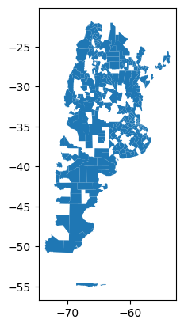

```python
merge = merge.set_geometry('geometry')
merge.plot()
```

### Exercise 6

Compute the neighbors of the capital city of your country. Plot the results for each of the options.

```python
provincias=gpd.read_file('https://github.com/valeriacaroe/Parte2/raw/refs/heads/main/provincia/provinciaPolygon.shp')

from libpysal.weights import Queen, Rook, KNN
```

```python
provincias.fna.unique()
```

```
array(['Ciudad Autónoma de Buenos Aires', 'Provincia de San Luis',
       'Provincia de Santa Fe', 'Provincia de La Rioja',
       'Provincia de Catamarca', 'Provincia de Tucumán',
       'Provincia del Chaco', 'Provincia de Formosa',
       'Provincia de Mendoza', 'Provincia de Entre Ríos',
       'Provincia de Jujuy', 'Provincia de Santiago del Estero',
       'Provincia de Corrientes', 'Provincia de Misiones',
       'Provincia de Salta', 'Provincia de Córdoba',
       'Provincia de Buenos Aires', 'Provincia de La Pampa',
       'Provincia de Tierra del Fuego, Antártida e Islas del Atlántico Sur',
       'Provincia de Santa Cruz', 'Provincia del Chubut',
       'Provincia de San Juan', 'Provincia de Río Negro',
       'Provincia del Neuquén'], dtype=object)
```

```python
w_rook = Rook.from_dataframe(provincias,use_index=False)
w_rook.islands
```

```
[18]
```

```python
w_queen = Queen.from_dataframe(provincias,use_index=False)
w_queen.islands
```

```
[18]
```

```python
%pip install folium matplotlib mapclassify -q
provincias.iloc[w_queen.islands,:].explore()
```

```
   ━━━━━━━━━━━━━━━━━━━━━━━━━━━━━━━━━━━━━━━━ 286.7/286.7 kB 9.4 MB/s eta 0:00:00
```

[interactive chart not shown]

```python
w_knn8 = KNN.from_dataframe(provincias, k=8)
w_knn8.islands
```

```
[]
```

```python
fila = provincias[provincias["fna"] == "Ciudad Autónoma de Buenos Aires"]
fila
```

|  | gid | entidad | fna | gna | nam | in1 | fdc | sag | geometry |
| --- | --- | --- | --- | --- | --- | --- | --- | --- | --- |
| 0 | 1 | 0.0 | Ciudad Autónoma de Buenos Aires | Ciudad Autónoma | Ciudad Autónoma de Buenos Aires | 02 | Geografía | IGN | POLYGON ((-58.45535 -34.52776, -58.45404 -34.5... |

```python
len(w_rook.neighbors[0]),len(w_queen.neighbors[0])
```

```
(1, 1)
```

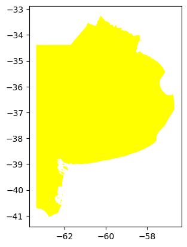

```python
provincias.iloc[w_rook.neighbors[0] ,].plot(facecolor="yellow")
```

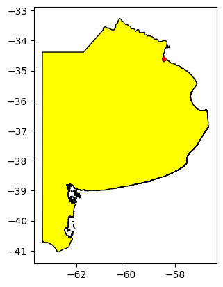

```python
base=provincias.iloc[w_rook.neighbors[0] ,].plot(facecolor="yellow",edgecolor='k')
provincias.loc[provincias.fna=='Ciudad Autónoma de Buenos Aires'].plot(ax=base,facecolor="red")
```

### Exercise 7

1. Compute the Moran's coefficient for one of your three numeric variables.
2. Make a scatter plot for each variable.

```python
%pip install esda -q
from esda.moran import Moran
```

```
   ━━━━━━━━━━━━━━━━━━━━━━━━━━━━━━━━━━━━━━━━ 142.8/142.8 kB 5.4 MB/s eta 0:00:00
```

```python
x = merge['N_HOGARES'].values
```

```python
w = KNN.from_dataframe(merge, k=8)
w.transform = 'r'
```

```python
moran = Moran(x, w)
```

```python
print(f"Moran's I: {moran.I:.4f}")
print(f"p-value: {moran.p_sim:.4f}")
```

```
Moran's I: 0.2670
p-value: 0.0010
```

```python
%pip install splot -q
from splot.esda import moran_scatterplot
```

```
   ━━━━━━━━━━━━━━━━━━━━━━━━━━━━━━━━━━━━━━━━ 61.3/61.3 kB 3.1 MB/s eta 0:00:00
   ━━━━━━━━━━━━━━━━━━━━━━━━━━━━━━━━━━━━━━━━ 389.9/389.9 kB 14.1 MB/s eta 0:00:00
   ━━━━━━━━━━━━━━━━━━━━━━━━━━━━━━━━━━━━━━━━ 322.8/322.8 kB 12.4 MB/s eta 0:00:00
```

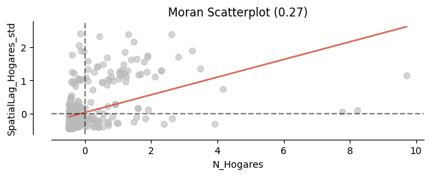

```python
fig, ax = moran_scatterplot(moran, aspect_equal=True)
ax.set_xlabel('N_Hogares')
ax.set_ylabel('SpatialLag_Hogares_std');
```

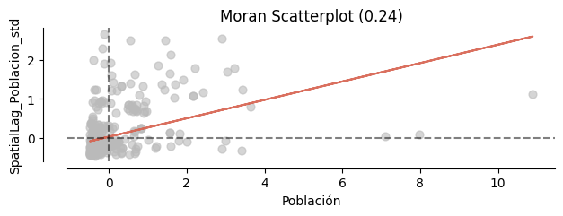

```python
moranPoblacion = Moran(merge['POBLACION'], w)
moranPoblacion.I,moranPoblacion.p_sim
fig, ax = moran_scatterplot(moranPoblacion, aspect_equal=True)
ax.set_xlabel('Población')
ax.set_ylabel('SpatialLag_Poblacion_std');
```

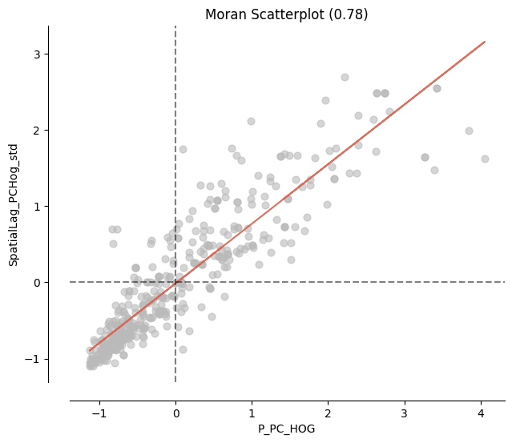

```python
moran3 = Moran(merge['P_PC_HOG'], w)
moran3.I,moran3.p_sim
fig, ax = moran_scatterplot(moran3, aspect_equal=True)
ax.set_xlabel('P_PC_HOG')
ax.set_ylabel('SpatialLag_PCHog_std');
```

### Exercise 8

1. Compute the Local Moran for the variables in your data that have significant spatial correlation.
2. Create a new column for each of those variables, with a label ('0 no_sig', '1 hotSpot', '2 coldOutlier', '3 coldSpot', '4 hotOutlier').
3. Prepare a map for each of the variables analyzed, showing the spots and outliers.

```python
merge.head()
```

|  | fna | N_HOGARES | POBLACION | P_PC_HOG | geometry |
| --- | --- | --- | --- | --- | --- |
| 0 | Departamento Ojo de Agua | 3784 | 13939 | 12.60 | POLYGON ((-64.05976 -28.8553, -64.05813 -28.85... |
| 1 | Departamento Choya | 9465 | 34635 | 10.92 | POLYGON ((-64.76325 -28.13958, -64.67495 -28.1... |
| 2 | Departamento Pilcaniyeu | 2360 | 7097 | 1.86 | POLYGON ((-69.77752 -39.88641, -69.77698 -39.8... |
| 3 | Comuna 1 | 84468 | 188280 | 1.38 | POLYGON ((-58.3863 -34.57819, -58.38606 -34.57... |
| 4 | Comuna 4 | 76455 | 215452 | 1.60 | MULTIPOLYGON (((-58.35525 -34.61933, -58.35515... |

```python
# A LISA for each district using IDH2019
from esda.moran import Moran_Local
lisaIDH = Moran_Local(y=merge['N_HOGARES'], w=w,seed=2022)
```

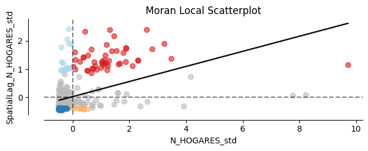

```python
fig, ax = moran_scatterplot(lisaIDH,p=0.05)
ax.set_xlabel('N_HOGARES_std')
ax.set_ylabel('SpatialLag_N_HOGARES_std');
```

```python
lisaIDH.q, lisaIDH.p_sim
```

[output not shown]

[output cut: 16 more lines]

[output not shown]

```python
import pandas as pd
pd.Series(lisaIDH.q).value_counts()
```

|  | count |
| --- | --- |
| 3 | 286 |
| 2 | 62 |
| 1 | 61 |
| 4 | 34 |

**dtype:** int64

```python
merge['N_HOG_quadrant']=[l if p <0.05 else 0 for l,p in zip(lisaIDH.q,lisaIDH.p_sim)  ]
merge['N_HOG_quadrant'].value_counts()
```

| N_HOG_quadrant | count |
| --- | --- |
| 0 | 309 |
| 3 | 62 |
| 1 | 48 |
| 2 | 17 |
| 4 | 7 |

**dtype:** int64

```python
labels = [ '0 no_sig', '1 hotSpot', '2 coldOutlier', '3 coldSpot', '4 hotOutlier']

merge['HOGARES_quadrant_names']=[labels[i] for i in merge['N_HOG_quadrant']]

merge['HOGARES_quadrant_names'].value_counts()
```

| HOGARES_quadrant_names | count |
| --- | --- |
| 0 no_sig | 309 |
| 3 coldSpot | 62 |
| 1 hotSpot | 48 |
| 2 coldOutlier | 17 |
| 4 hotOutlier | 7 |

**dtype:** int64

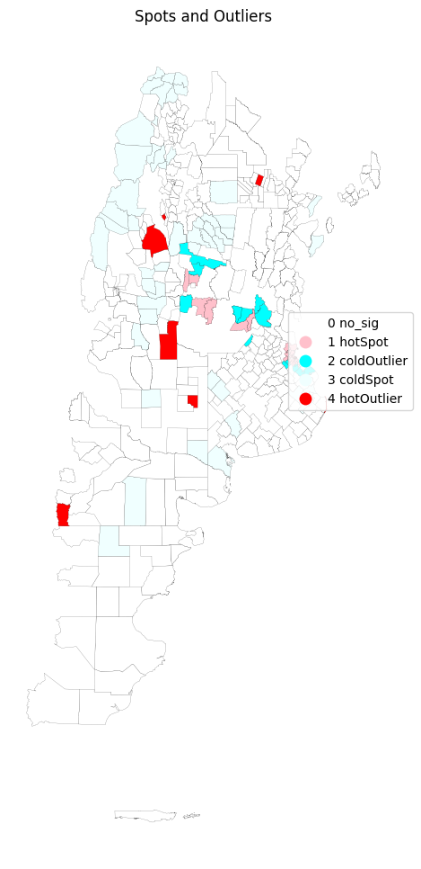

```python
# custom colors
from matplotlib import colors
import matplotlib.pyplot as plt

myColMap = colors.ListedColormap([ 'white', 'pink', 'cyan', 'azure','red'])

# Set up figure and ax
f, ax = plt.subplots(1, figsize=(12,12))
# Plot unique values choropleth including
# a legend and with no boundary lines

plt.title('Spots and Outliers')

merge.plot(column='HOGARES_quadrant_names',
                categorical=True,
                cmap=myColMap,
                linewidth=0.1,
                edgecolor='k',
                legend=True,
                legend_kwds={'loc': 'center left',
                             'bbox_to_anchor': (0.7, 0.6)},
                ax=ax)
# Remove axis
ax.set_axis_off()
# Display the map
plt.show()
```

Exercise 9 Use your three variables to carry out the cluster/regional analysis.

```python
merge.head()
```

|  | fna | N_HOGARES | POBLACION | P_PC_HOG | geometry | N_HOG_quadrant | HOGARES_quadrant_names |
| --- | --- | --- | --- | --- | --- | --- | --- |
| 0 | Departamento Ojo de Agua | 3784 | 13939 | 12.60 | POLYGON ((-64.05976 -28.8553, -64.05813 -28.85... | 3 | 3 coldSpot |
| 1 | Departamento Choya | 9465 | 34635 | 10.92 | POLYGON ((-64.76325 -28.13958, -64.67495 -28.1... | 0 | 0 no_sig |
| 2 | Departamento Pilcaniyeu | 2360 | 7097 | 1.86 | POLYGON ((-69.77752 -39.88641, -69.77698 -39.8... | 0 | 0 no_sig |
| 3 | Comuna 1 | 84468 | 188280 | 1.38 | POLYGON ((-58.3863 -34.57819, -58.38606 -34.57... | 1 | 1 hotSpot |
| 4 | Comuna 4 | 76455 | 215452 | 1.60 | MULTIPOLYGON (((-58.35525 -34.61933, -58.35515... | 1 | 1 hotSpot |

```python
!pip install mapclassify
```

```python
import mapclassify
import numpy as np
np.random.seed(12345)

theVar=merge.N_HOGARES
K=5
#
ei5 = mapclassify.EqualInterval(theVar, k=K)
#
msd = mapclassify.StdMean(theVar)
#
q5=mapclassify.Quantiles(theVar,k=K)
#
mb5 = mapclassify.MaximumBreaks(theVar, k=K)
#
ht = mapclassify.HeadTailBreaks(theVar)
#
fj5 = mapclassify.FisherJenks(theVar, k=K)
#
jc5 = mapclassify.JenksCaspall(theVar, k=K)
#
mp5 = mapclassify.MaxP(theVar, k=K)
```

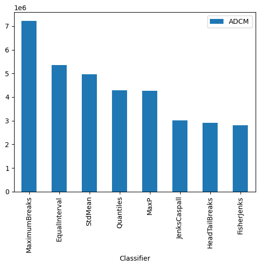

```python
import seaborn
class5 = q5, ei5,msd, ht, mb5, fj5, jc5, mp5
# Collect ADCM for each classifier
fits = np.array([ c.adcm for c in class5])
# Convert ADCM scores to a DataFrame
adcms = pd.DataFrame(fits)
# Add classifier names
adcms['classifier'] = [c.name for c in class5]
# Add column names to the ADCM
adcms.columns = ['ADCM', 'Classifier']
adcms.sort_values(by='ADCM', ascending=False).plot(kind='bar', x='Classifier', y='ADCM')
```

```python
merge['N_HOGARES']=fj5.yb
```

```python
theVar=merge.POBLACION
K=5
#
ei51 = mapclassify.EqualInterval(theVar, k=K)
#
msd1 = mapclassify.StdMean(theVar)
#
q51=mapclassify.Quantiles(theVar,k=K)
#
mb51 = mapclassify.MaximumBreaks(theVar, k=K)
#
ht1 = mapclassify.HeadTailBreaks(theVar)
#
fj51 = mapclassify.FisherJenks(theVar, k=K)
#
jc51 = mapclassify.JenksCaspall(theVar, k=K)
#
mp51 = mapclassify.MaxP(theVar, k=K)
```

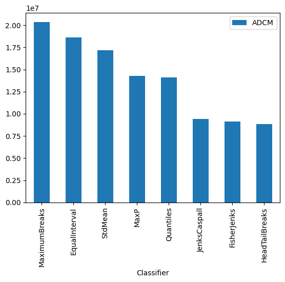

```python
class51 = q51, ei51,msd1, ht1, mb51, fj51, jc51, mp51
# Collect ADCM for each classifier
fits = np.array([ c.adcm for c in class51])
# Convert ADCM scores to a DataFrame
adcms = pd.DataFrame(fits)
# Add classifier names
adcms['classifier'] = [c.name for c in class51]
# Add column names to the ADCM
adcms.columns = ['ADCM', 'Classifier']
adcms.sort_values(by='ADCM', ascending=False).plot(kind='bar', x='Classifier', y='ADCM')
```

```python
merge['POBLACION']=ht1.yb
```

```python
theVar=merge.P_PC_HOG
K=5
#
ei52 = mapclassify.EqualInterval(theVar, k=K)
#
msd2 = mapclassify.StdMean(theVar)
#
q52=mapclassify.Quantiles(theVar,k=K)
#
mb52 = mapclassify.MaximumBreaks(theVar, k=K)
#
ht2 = mapclassify.HeadTailBreaks(theVar)
#
fj52 = mapclassify.FisherJenks(theVar, k=K)
#
jc52 = mapclassify.JenksCaspall(theVar, k=K)
#
mp52 = mapclassify.MaxP(theVar, k=K)
```

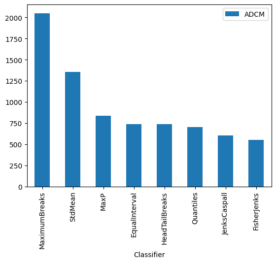

```python
class52 = q52, ei52,msd2, ht2, mb52, fj52, jc52, mp52
# Collect ADCM for each classifier
fits = np.array([ c.adcm for c in class52])
# Convert ADCM scores to a DataFrame
adcms = pd.DataFrame(fits)
# Add classifier names
adcms['classifier'] = [c.name for c in class52]
# Add column names to the ADCM
adcms.columns = ['ADCM', 'Classifier']
adcms.sort_values(by='ADCM', ascending=False).plot(kind='bar', x='Classifier', y='ADCM')
```

```python
merge['P_PC_HOG']=ht2.yb
```

```python
selected_variables = ['N_HOGARES',
                     'POBLACION',
                     'P_PC_HOG']
```

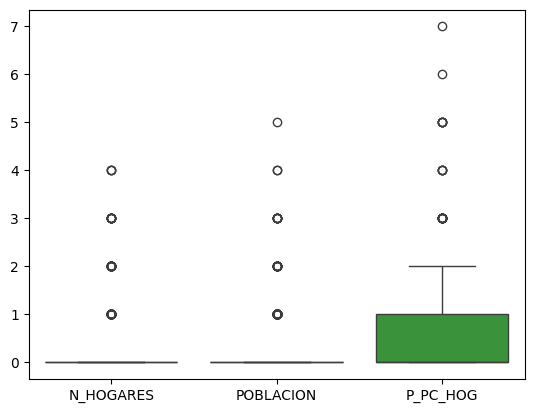

```python
import seaborn as sns
sns.boxplot(merge[selected_variables])
```

```python
merge[selected_variables].corr()
```

|  | N_HOGARES | POBLACION | P_PC_HOG |
| --- | --- | --- | --- |
| N_HOGARES | 1.00000 | 0.948200 | -0.237020 |
| POBLACION | 0.94820 | 1.000000 | -0.218886 |
| P_PC_HOG | -0.23702 | -0.218886 | 1.000000 |

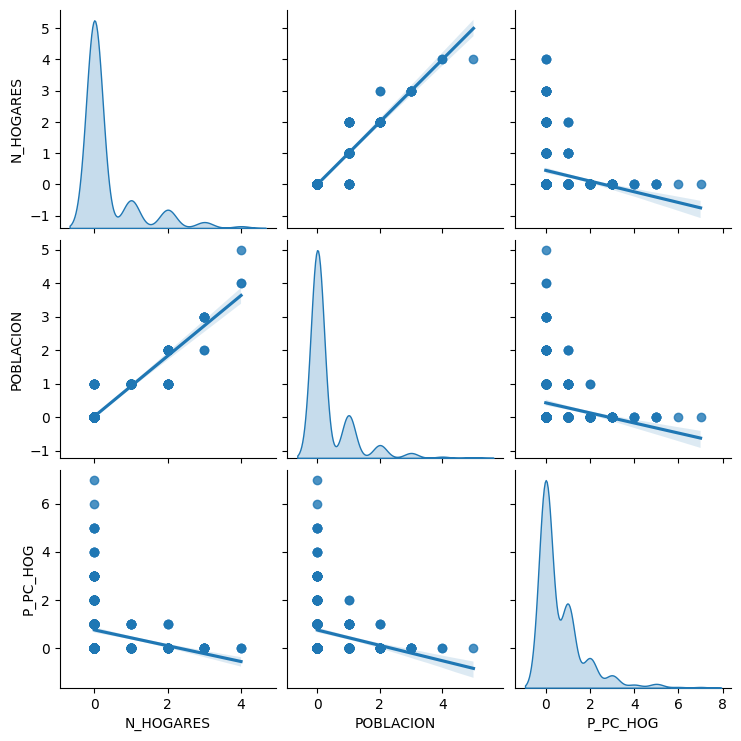

```python
import seaborn as sns
sns.pairplot(
    merge[selected_variables], kind="reg", diag_kind="kde"
)
```

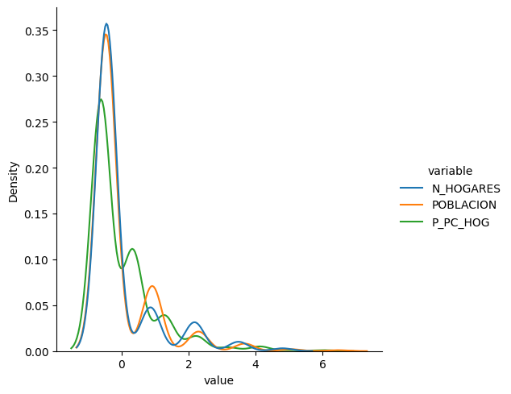

```python
from sklearn.preprocessing import StandardScaler


scaler = StandardScaler()
normalized_data = scaler.fit_transform(merge[selected_variables])
sns.displot(pd.melt(pd.DataFrame(normalized_data,columns=selected_variables)),
            x="value", hue="variable",kind="kde",
            log_scale=(False,False))
```

```python
selected_variables_new_std=[s+'_std' for s in selected_variables]

# add colunms
merge[selected_variables_new_std]=normalized_data
```

Conventional Clustering

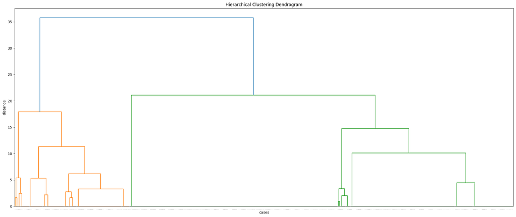

```python
from scipy.cluster import hierarchy as hc


Z = hc.linkage(merge[selected_variables_new_std], 'ward')
# calculate full dendrogram
plt.figure(figsize=(25, 10))
plt.title('Hierarchical Clustering Dendrogram')
plt.xlabel('cases')
plt.ylabel('distance')
hc.dendrogram(
    Z,
    leaf_rotation=90.,  # rotates the x axis labels
    leaf_font_size=1,  # font size for the x axis labels
)
plt.show()
```

```python
from sklearn.cluster import AgglomerativeClustering as agnes

import numpy as np
np.random.seed(12345)# Set seed for reproducibility

model = agnes(linkage="ward", n_clusters=6).fit(merge[selected_variables_new_std])

# Assign labels to main data table
merge["hc_ag6"] = model.labels_
```

```python
merge["hc_ag6"].value_counts()
```

| hc_ag6 | count |
| --- | --- |
| 5 | 185 |
| 0 | 145 |
| 1 | 58 |
| 2 | 31 |
| 3 | 13 |
| 4 | 11 |

**dtype:** int64

```python
merge.groupby("hc_ag6")[selected_variables_new_std].mean()
```

| hc_ag6 | N_HOGARES_std | POBLACION_std | P_PC_HOG_std |
| --- | --- | --- | --- |
| 0 | -0.447055 | -0.463889 | 0.780214 |
| 1 | 0.615760 | 0.915324 | -0.350358 |
| 2 | 2.176061 | 1.760648 | -0.520060 |
| 3 | 3.790287 | 3.885936 | -0.611762 |
| 4 | -0.447055 | -0.463889 | 4.040042 |
| 5 | -0.447055 | -0.463889 | -0.611762 |

PRIMER INTENTO DE FORMAR LOS CLUSTER

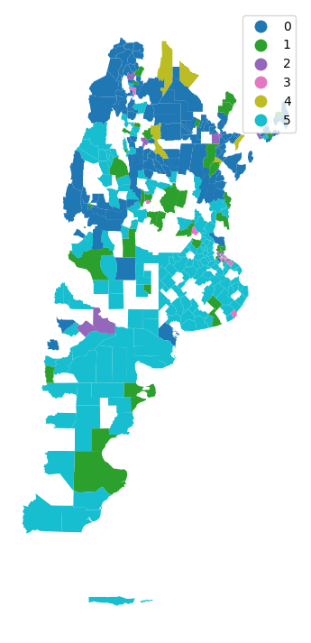

```python
# Set up figure and ax
f, ax = plt.subplots(1, figsize=(9, 9))
# Plot unique values choropleth including
# a legend and with no boundary lines
merge.plot(
    column="hc_ag6", categorical=True, legend=True, linewidth=0, ax=ax
)
# Remove axis
ax.set_axis_off()
# Display the map
plt.show()
```

```python
from sklearn.cluster import AgglomerativeClustering as agnes
from libpysal.weights import Queen

w_queen_merge = Queen.from_dataframe(merge)

model_queen = agnes(linkage="ward",
                    n_clusters=6,
                    connectivity=w_queen_merge.sparse).fit(merge[selected_variables_new_std])
#
merge["hc_ag6_wQueen"] = model_queen.labels_
```

VERSIÓN MEJORADA, PERO AÚN EXISTEN CIERTAS ISLAS

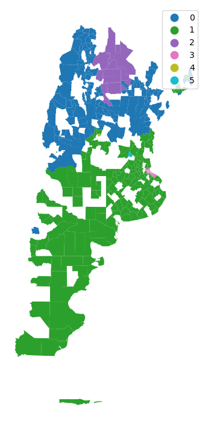

```python
# Set up figure and ax
f, ax = plt.subplots(1, figsize=(9, 9))
# Plot unique values choropleth including
# a legend and with no boundary lines
merge.plot(
    column="hc_ag6_wQueen", categorical=True, legend=True, linewidth=0, ax=ax
)
# Remove axis
ax.set_axis_off()
# Display the map
plt.show()
```

Estos son los patrones identificados, cuando se fuerza la continuidad de los cluster formados en el mapa de argentina.